# Bias Demo - sample mean & variance

This activity is a demo of sample statistics being (un)biased estimators of their population parameters. We will examine $\overline{X}$ as an estimator for $\mu$ and the sample variance $s^2$ as an estimator for $\sigma^2$.

## Load packages

We first need to load the `tidyverse`, `dslabs`, and `infer` packages using the `library()` command.

```r
library(tidyverse)
library(dslabs)
library(infer)
```

## Prepare the data

We can load a dataset called `gapminder` that contains data on 185 countries from the years 1960 to 2016. We are going to consider the distribution of the variable `life_expectancy`.

```r
data("gapminder", package = "dslabs")
```

Let’s first `filter` the data to keep only the year 2015.

```r
gapminder_2015 <- gapminder %>%
  filter(year == 2015)
```

`gapminder_2015` has data on life expectancy for 185 countries. We will consider this to be our population. We can visualize the distribution of `life_expectancy` with a histogram.

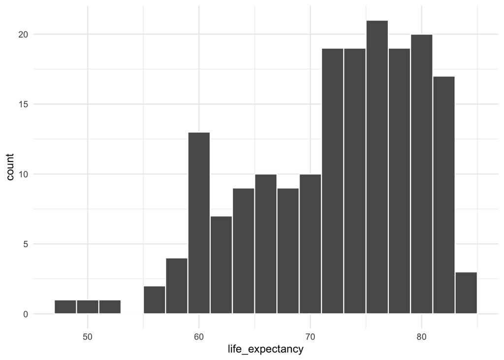

```r
ggplot(gapminder_2015, aes(x = life_expectancy)) +
  geom_histogram(color = "white", binwidth = 2) +
  theme_minimal()
```

## Population mean & Sample mean

We can compute the true mean $\mu$ life expectancy in the population by:

```r
gapminder_2015 %>%
  summarize(n = n(),
            mu = sum(life_expectancy)/n)
```

```
    n       mu
1 185 72.21459
```

Suppose we don’t have access to this population level data and instead only have data on a random sample of 5 countries. This means we don’t know $\mu$ but have to estimate it.

Let’s draw a random sample of size 5 and compute the sample mean.

```r
sample <- gapminder_2015 %>%
  sample_n(5)
sample
```

```
           country year infant_mortality life_expectancy fertility population
1        Sri Lanka 2015              8.4            77.6      2.31   20715010
2 Papua New Guinea 2015             44.5            60.9      3.67    7619321
3          Belgium 2015              3.3            80.5      1.86   11299192
4      Switzerland 2015              3.4            83.0      1.55    8298663
5         Suriname 2015             19.0            72.0      2.22     542975
  gdp continent         region
1  NA      Asia  Southern Asia
2  NA   Oceania      Melanesia
3  NA    Europe Western Europe
4  NA    Europe Western Europe
5  NA  Americas  South America
```

```r
sample %>%
  summarize(n = n(),
            xbar = mean(life_expectancy))
```

```
  n xbar
1 5 74.8
```

Recall that for an estimator to be unbiased, it doesn’t mean each estimate “hits the target” (equals $\mu$) EVERY time, but that *on average* (in the long run) it hits the correct target (is centered around the correct value).

We can draw 10,000 random samples of size 5 and compute the sample mean in each sample with the following code:

```r
means <- rep_sample_n(gapminder_2015, size = 5, reps = 10000) %>%
  group_by(replicate) %>%
  summarize(n = n(),
            xbar = sum(life_expectancy)/n)
```

We now have 10,000 $\overline{X}$ estimates, from 10,000 different random samples. We can look at the distribution of these 10,000 values.

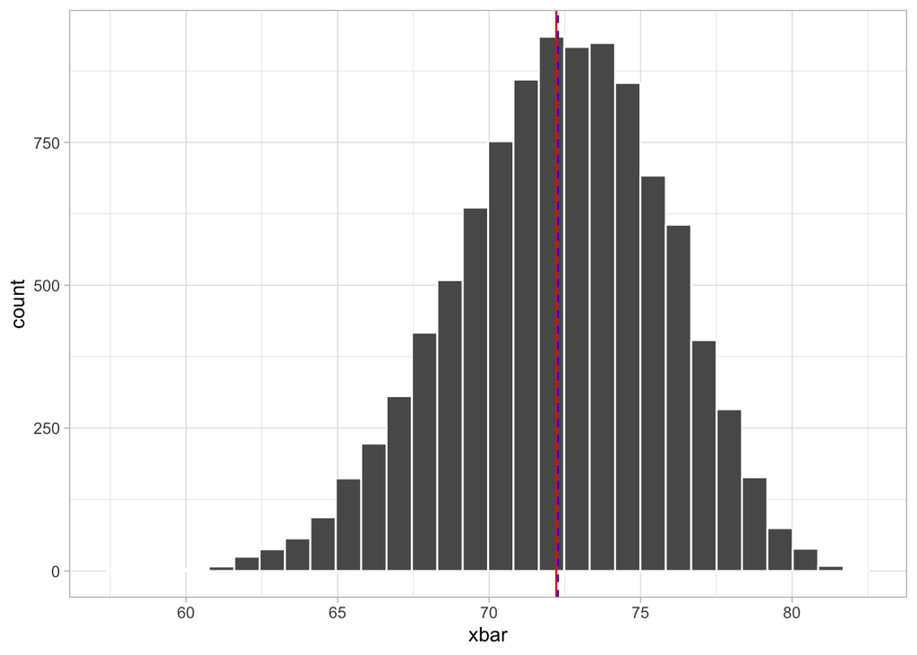

```r
ggplot(means, aes(x = xbar)) +
  geom_histogram(color = "white") +
  geom_vline(xintercept = mean(gapminder_2015$life_expectancy),
             color = "red") +
  geom_vline(xintercept = mean(means$xbar),
             color = "blue", linetype = 2) +
  theme_light()
```

We can calculate $E(\overline{X})$ (the long-run average of the sample mean).

```r
means %>%
  summarize(Exbar = mean(xbar))
```

```
# A tibble: 1 × 1
  Exbar
  <dbl>
1  72.3
```

Since the sample mean $\overline{X}$ is an unbiased estimator of the population mean $\mu$, we have $E(\overline{X}) = \mu$.

## Population variance and sample variance

Recall that we can compute the true variance $\sigma^2$ of life expectancy in the population by:

```r
gapminder_2015 %>%
  summarize(sigma2 = var(life_expectancy))
```

```
    sigma2
1 60.69472
```

Suppose we don’t have access to this population level data and instead only have data on a random sample of 5 countries. This means we don’t know $\sigma^2$ but have to estimate it. Let’s consider two possible ways to estimate $\sigma^2$ from our sample data:

1. $s^2_n = \frac{\sum_{i = 1}^n (x_i - \overline{x})^2}{n}$
2. $s^2 = \frac{\sum_{i = 1}^n (x_i - \overline{x})^2}{n-1}$

Let’s draw a random sample of size 5 and compute these two estimates from our sample data.

```r
sample <- gapminder_2015 %>%
  sample_n(5)
sample
```

```
     country year infant_mortality life_expectancy fertility population gdp
1      Qatar 2015              6.8            79.7      1.98    2235355  NA
2 Mozambique 2015             56.7            57.1      5.04   27977863  NA
3      Japan 2015              2.0            83.2      1.45  126573481  NA
4     Poland 2015              4.5            77.6      1.44   38611794  NA
5   Colombia 2015             13.6            78.0      2.23   48228704  NA
  continent         region
1      Asia   Western Asia
2    Africa Eastern Africa
3      Asia   Eastern Asia
4    Europe Eastern Europe
5  Americas  South America
```

```r
sample %>%
  summarize(n = n(),
            xbar = sum(life_expectancy)/n,
            s2_n = sum((life_expectancy - mean(life_expectancy))^2) / n,
            s2 = sum((life_expectancy - mean(life_expectancy))^2) / (n - 1))
```

```
  n  xbar    s2_n      s2
1 5 75.12 85.0856 106.357
```

Which one is a better estimate of $\sigma^2$? Remember that $s^2_n$ and $s^2$ are both random variables because they are functions of the random variables $x_i$ (the life expectancy in the randomly selected country $i$). If we were to draw a different random sample, it might be the case that the other estimator gave us a “better” estimate (closer to the true $\sigma^2$). In order to see which one is best in the long-run, let’s run 10,000 simulations, by taking 10,000 random samples and computing the two variance estimates in each.

```r
variances <- rep_sample_n(gapminder_2015, size = 5, reps = 10000) %>%
  group_by(replicate) %>%
  summarize(n = n(),
            xbar = sum(life_expectancy)/n,
            s2_n = sum((life_expectancy - mean(life_expectancy))^2) / n,
            s2 = sum((life_expectancy - mean(life_expectancy))^2) / (n - 1))
```

Let’s now compute the expected value (average) of each estimator.

```r
variances %>%
  summarize(Exbar = mean(xbar),
            Es2_n = mean(s2_n),
            Es2 = mean(s2))
```

```
# A tibble: 1 × 3
  Exbar Es2_n   Es2
  <dbl> <dbl> <dbl>
1  72.2  48.7  60.9
```

Which one is closer to the true $\sigma^2$ value?

As these results indicate, $s^2_n = \frac{\sum_{i = 1}^n (x_i - \overline{x})^2}{n}$ is a *biased* estimator of $\sigma^2$. In other words, it’s expected value is not equal to $\sigma^2$; in the long-run, on average, it does not “hit the target” and estimate the correct value.

Dividing by $n-1$, however, as in $s^2 = \frac{\sum_{i = 1}^n (x_i - \overline{x})^2}{n - 1}$, gets rid of the bias and does “hit the correct target”. That is, $E(s^2) = \sigma^2$.

The following histograms show the bias visually:

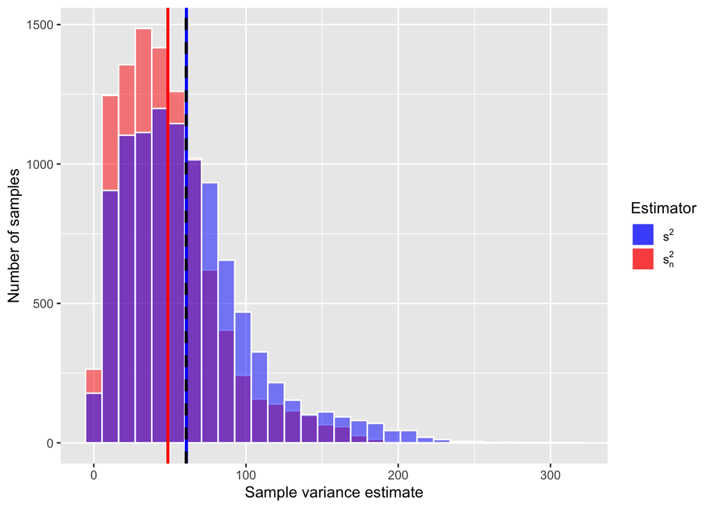